# Demostración

Rubén Muñoz

```r
#Librerías a usar
library(tidyr)
library(dplyr)
# Cargar los datos a usar
population <- gm_data
```

## Prueba de t de Student

La CONABIO realizó un estudio de la vegetación en en el bosque tropical del Sur de México. Uno de los objetivos de este muestreo es conocer los impactos de la perturbación antropógénica sobre las poblaciones de árboles nativos de la región. Por lo que se quiere conocer si el DAP promedio de los árboles de *Ceiba pentandra* en el bosque tropical del Sur de México difiere del promedio de los árboles encontrados en sistemas silvopastoriles de la misma región. ¿Qué tipo de prueba estadística se debe aplicar?

- **Prueba de t de Student para muestras independientes** (Paramétrica)
- **Prueba de U de Mann-Whitney** (No paramétrica)

Si la prueba muestra diferencias significativas ¿cuál de los siguientes dos gráficos representa mejor el experiemnto?

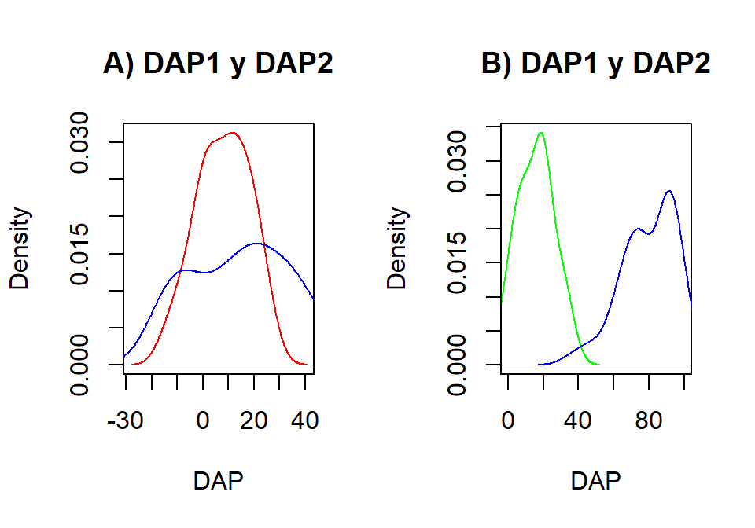

```r
par(mfrow = c(1,2))
plot(density(DAP1), main = "A) DAP1 y DAP2",
     xlab = "DAP",
     col = "red") +
lines(density(DAP2), col= "blue")

plot(density(DAP1_2), main = "B) DAP1 y DAP2",
     xlab = "DAP", xlim = c(0,100),
     col = "green") +
lines(density(DAP2_2), col= "blue")
```

## ANOVA

De acuerdo al siguiente gráfico ¿Qué tipo de prueba se debería realizar si se quiere conocer si hay diferencias significativas?

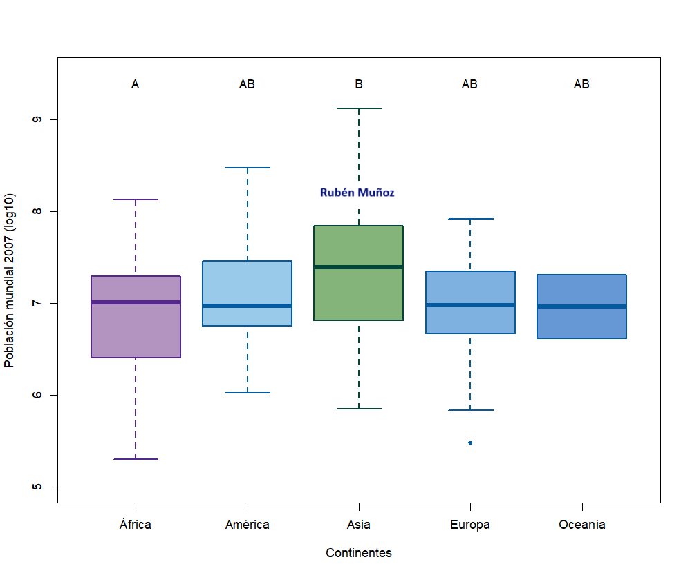

Debido a que se está considerando la población humana por continente (1 grupo). Se debe realizar la prueba de:

- **ANOVA de una vía** (paramétrica)

Al establecer una prueba post-hoc para este set de datos ¿Qué podemos afirmar con los siguientes resultados?

```r
# Prueba post-hoc
TukeyOneway
```

```
##  Americas-Africa      Asia-Africa    Europe-Africa   Oceania-Africa
##            0.986            0.023            1.000            1.000
##    Asia-Americas  Europe-Americas Oceania-Americas      Europe-Asia
##            0.234            0.993            0.999            0.069
##     Oceania-Asia   Oceania-Europe
##            0.862            1.000
```

Únicamente Asia y África presentan diferencias significativas entre sus poblaciones promedio.

Si quisieramos conocer cómo ha cambiado la tendencia poblacional de 1950 a 2007 tomando en cuenta los datos por continentes así como la interacción ente años y continente. ¿Qué tipo de prueba aplicarías? (normalidad de los datos)

- **ANOVA de dos vías**

¿Qué se puede afirmar del siguiente resultado de la prueba anterior?

```r
# Resultado de la prueba
ANOVA_ADD
```

```
##                 Df F value   Pr(>F)
## continent        4  4.3284 0.002067 **
## year             1  4.3295 0.038387 *
## continent:year   4  0.9924 0.412059
## Residuals      274
## ---
## Signif. codes:  0 '***' 0.001 '**' 0.01 '*' 0.05 '.' 0.1 ' ' 1
```

## Pruebas de correlación

Se busca conocer la asociación entre el PIB y la esperanza de vida promedio. De acuerdo al siguiente gráfico ¿Qué tipo de prueba usarías?

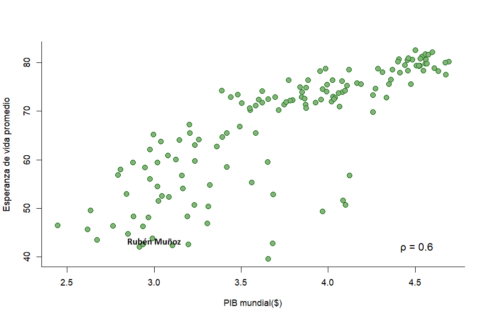

- **Prueba de correlación de Pearson** (paramétrica)

¿Qué tipo de correlación hay entre las variables?

1. logísitica
2. neutra de sentido opuesto
3. negativa exponencial
4. positiva

## Prueba de chi cuadrada $\chi^{2}$

¿ Qué tipo de prueba permite comparar lo observado contra lo esperado con datos categóricos?

1. Regresión lineal
2. Prueba de t pareada
3. Prueba de chi cuadrada
4. Prueba de Higgs

**Ejemplo.** Se realizó la cruza de individuos de la especie *Iris versicolor*, unas con el rasgo de flores rojas y otras con flores blancas. Por lo que se obtuvo una descendecnia de: F1: 79 individuos con flores rojas y 27 con flores blancas.

Se sospecha que el patrón de herencia es de dominancia-recesividad. ¿Cuál es la proporción fenotípica que sigue este patrón y cómo podría comprobarse?

1. 1:3:1, prueba de independencia de $\chi^{2}$
2. 3:1, prueba de $\chi^{2}$ de bondad de ajuste
3. 1:2, ANOVA de dos vías

De acuerdo con los siguientes datos arrojados de la prueba de bondad de ajuste y considerando que el estadístico $\chi^{2}$ esperado para esta prueba es de 3.84. ¿Qué podemos concluir de la prueba?

```r
PruebaX
```

```
##
##  Chi-squared test for given probabilities
##
## data:  fenotipoObservado
## X-squared = 0.012579, df = 1, p-value = 0.9107
```

1. La frecuencia observada no sigue una proporción 3:1
2. La frecuencia esperada es en promedio menor que la observada
3. La frecuancia observada sigue una proporción fenotípica de dominacia recesividad

**¡Espero que estos apuntes te hayan sido útiles para prepararte para el examen! Si te interesa profundizar tus habilidades en manejo de datos, realizar análisis estadísticos y visualizar tus resultados de manera efectiva, no dudes en contactarme. Ofrezco cursos de manejo de R desde cero.**

Contacto:

- **rm.clases.r@gmail.com**